# SF-Seq

# **Part 3 - rRNA reads and strand-specificity**

# **6.**

gmap-gsnap/2017-09-11 was used to generate our gmap database and used to run our gsnap commands.

My gmap database was built on an interactive node using the following command after obtaining the desired non-coding RNA fasta file from Ensembl and editing it to only include the rRNA enteries.

```
#Editing the fasta file to only include rRNA enteries
cat Mus_musculus.GRCm38.ncrna.fa | grep 'transcript_biotype:rRNA' -A 1 > gmapbuild.fa
```

gmap build script:

```
#Loading required modules
module load easybuild
module load GCC/6.3.0-2.27
module load OpenMPI/2.0.2
Module load gmap-gsnap/2017-09-11
#Building my mouse database with the file generated above form Ensembl
gmap_build -D /home/rmeng/Bi624/SF-Seq/gmap/ -d Mouse gmapbuild.fa
```

gsnap script:

```
#!/bin/bash
#SBATCH --job-name=Velveth      ### Job Name
#SBATCH --time=0-24:00:00       ### Wall clock time limit in Days-HH:MM:SS
#SBATCH --nodes=1               ### Node count required for the job
#SBATCH --ntasks-per-node=28     ### Number of tasks to be launched per Node
#SBATCH --partition=short       ### Partition (like a queue in PBS)

#Loading the required modules.
module load easybuild
module load GCC/6.3.0-2.27
module load OpenMPI/2.0.2
module load gmap-gsnap/2017-09-11

#Using my gsnap command with the paired-end format
gsnap -D /home/rmeng/Bi624/SF-Seq/gmap/Mouse -d Mouse -B 4 -m 20 -t 8 -O --split-output
gsnap_out -A sam --allow-pe-name-mismatch /home/rmeng/Bi624/SF-Seq/out.23_4A_control_S17_L008_R1_001.fastq /home/rmeng/Bi624/SF-Seq/out.23_4A_control_S17_L008_R2_001.fastq

#My two gsnap commands were in seperate scripts and were exactly the same except for the the files input as shown below
gsnap -D /home/rmeng/Bi624/SF-Seq/gmap/Mouse -d Mouse -B 4 -m 20 -t 8 -O --split-output gsnap_out -A sam --allow-pe-name-mismatch /home/rmeng/Bi624/SF-Seq/out.3_2B_control_S3_L008_R1_001.fastq /home/rmeng/Bi624/SF-Seq/out.3_2B_control_S3_L008_R2_001.fastq
```

Calculating the proportion of reads that mapped back for each pair of my files:

```
wc -l out.23_4A_control_S17_L008_R1_001.fastq
177213048 out.23_4A_control_S17_L008_R1_001.fastq
```

```
wc -l out.23_4A_control_S17_L008_R2_001.fastq
177213048 out.23_4A_control_S17_L008_R2_001.fastq
```

177213048/4 = 44,303,262*2 = 88,606,524

```
cat gsnap_out.nomapping | grep -v '^@' | wc -l
88500923
```

1-(88,500,923/88,606,524) = **0.11917% of reads likely came from rRNA for 23_4A Control**

```
wc -l out.3_2B_control_S3_L008_R1_001.fastq
27494036 out.3_2B_control_S3_L008_R1_001.fastq
```

```
wc -l out.3_2B_control_S3_L008_R2_001.fastq
27494036 out.3_2B_control_S3_L008_R2_001.fastq
```

27494036 / 4 = 6,873,509 * 2 = 13,747,018

```
cat gsnap_out.nomapping | grep -v '^@' | wc -l
13744583
```

1-(13,744,583/13,747,018) = **0.0177% of reads likely came from rRNA for 3_2B control**

# **7**

To determine strand specificity, I grepped for 20 consecutive A’s and T’s in each file and have shown the results both numerically and graphically.

Sample Command:

```
awk 'NR % 4 == 2' 3_2B_control_S3_L008_R1_001.fastq | grep 'TTTTTTTTTTTTTTTTTTTT' | wc -l

awk 'NR % 4 == 2' 3_2B_control_S3_L008_R1_001.fastq | grep 'AAAAAAAAAAAAAAAAAAAA' | wc -l
```

Results:

23_4A_R1 Poly A 21152

23_4A_R2 Poly A **45030**

23_4A_R1 Poly T **141142**

23_4A_R2 Poly T 46005

3_2B_R1 Poly A 3368

3_2B_R2 Poly A **7568**

3_2B_R1 Poly T **24968**

3_2B_R2 Poly T 8278

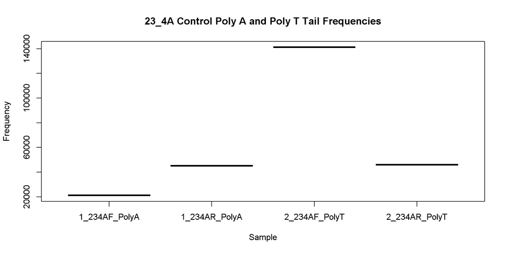

```r
test100 <-read.table('test100.txt', sep = '')
plot(test100$V2~test100$V1, main = '23_4A Control Poly A and Poly T Tail Frequencies', xlab = 'Sample', ylab = 'Frequency')
```

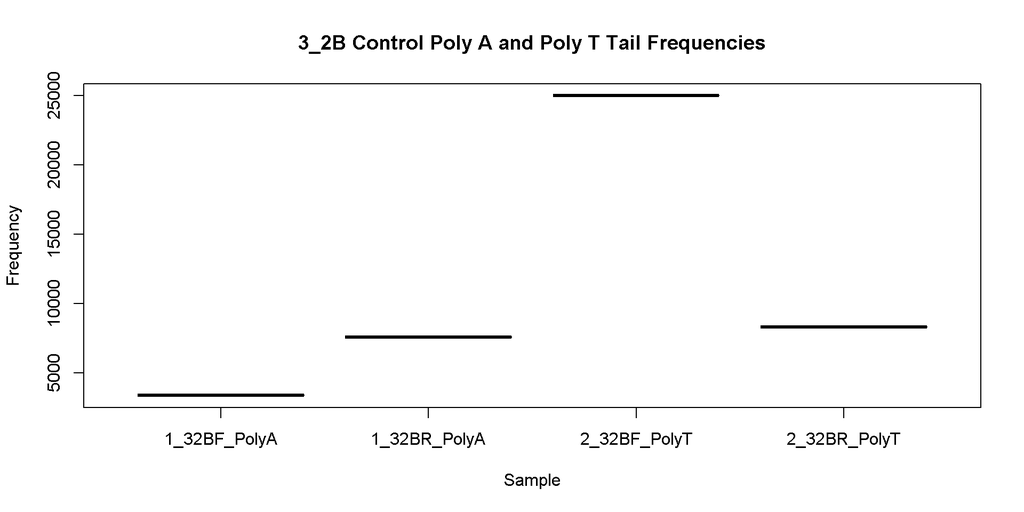

```r
test101 <-read.table('test101.txt', sep = '')
plot(test101$V2~test101$V1, main = '3_2B Control Poly A and Poly T Tail Frequencies', xlab = 'Sample', ylab = 'Frequency')
```

The stark differences between the two files in terms of strands of consecutive T’s and consecutive A’s is indicitive of strandness.